# Estimating Demographics and Other Characteristics for Custom Spatial Features – Example Workflow

Accessing U.S. Census Bureau Data & Calculating Weighted Averages with Areal Weighted Interpolation

## 1 Background

This document is intended to provide an example of how to use tools available from the [R programming language](https://www.R-project.org/) (R Core Team 2023) to estimate characteristics of any given ‘target’ spatial area(s) (e.g., neighborhoods, project boundaries, water supplier service areas, etc.), based on data from a source dataset containing the characteristic data of interest (e.g., census data, CalEnvrioScreen scores, etc.) whose boundaries overlap but don’t necessarily align with the target area(s). It also provides some brief background on the various types of data available from the U.S Census Bureau, and links to a few places to find more in-depth information.

This particular example estimates demographic characteristics of community water systems in the Sacramento County area. It uses the [`tidycensus`](https://walker-data.com/tidycensus/index.html) R package (Walker and Herman 2023) to access selected demographic data from the U.S. Census Bureau for census units whose spatial extent covers those water systems’ service areas, then uses the [`areal`](https://chris-prener.github.io/areal/) R package (Prener et al. 2019) to estimate some demographic characteristics of each water system based on that census data. It also relies on a number of other R packages, such as the [`tidyverse`](https://www.tidyverse.org/) collection of packages (Wickham et al. 2019) for general data management and analysis, and the [`sf`](https://r-spatial.github.io/sf/) package (Pebesma and Bivand 2023) for working with spatial data.

This example is just intended to be a simplified demonstration of a possible workflow. For a real analysis, additional steps and considerations – that may not be covered here – may be needed to deal with data inconsistencies (e.g., missing or incomplete data), required level of precision and acceptable assumptions (e.g. more fine-grained datasets or more sophisticated techniques could be used to estimate/model population distributions), or other project-specific issues that might arise.

## 2 Setup

The code block below loads required packages for this analysis, and sets some user-defined options and defaults.

```r
# packages ----
library(tidycensus)
library(tigris)
library(tidyverse)
library(sf)
library(janitor)
library(here)
library(units)
library(areal)
library(Polychrome)
library(knitr)
library(kableExtra)
library(tmap)
library(patchwork)
library(scales)
library(digest)

# options ----
options(scipen = 999) # turn off scientific notation
options(tigris_use_cache = TRUE) # use data caching for tigris

# reference system ----
crs_projected <- 3310 # set a common projected coordinate reference system to be used throughout this analysis - see: https://epsg.io/3310
```

## 3 Water System Boundaries (Target Data)

In this section, we’ll get the service area boundaries for Community Water Systems within the Sacramento County area. This will serve as the ‘target’ dataset – i.e., the set of areas which we’ll be estimating the characteristics of. We’ll also get a dataset of county boundaries which overlap the water service areas in this study, which will help with accessing the census data and with making maps/visualizations.

### 3.1 Read Water System Data

In this case, we’ll get the water system dataset from a shapefile that’s saved locally, then transform that dataset into a common coordinate reference system for mapping and analysis (which is defined above in the variable `crs_projected`).

This water system dataset is a subset of the [California Drinking Water System Area Boundaries dataset](https://gispublic.waterboards.ca.gov/portal/home/item.html?id=fbba842bf134497c9d611ad506ec48cc). I created the subset used here by filtering the full dataset for systems within Sacramento County (by selecting records where the `COUNTY` field is “SACRAMENTO”) and filtering for Community Water Systems (by selecting records where the `STATE_CLAS` field is “COMMUNITY”). I also dropped some un-needed fields from the dataset and reordered some columns.

```r
water_systems_sac <- st_read(here('01_data_input',
                                  'water_supplier_boundaries_sac',
                                  'System_Area_Boundary_Layer_Sac.shp')) %>%
    st_transform(crs_projected) # transform to common coordinate system
```

As an alternative, the code chunk below shows how to download this data directly from the online source dataset and apply the filters needed to reproduce the dataset in the `System_Area_Boundary_Layer_Sac.shp` file, using the [`arcgislayers`](https://r.esri.com/arcgislayers/index.html) package (Parry 2023). This code is commented out (with the `#` symbol), since it gives the same dataset as is contained in the shapefile that’s read in above, but is included here as a reference for a more direct alternative way to obtain the current version of the target dataset. Note that, since this method is accessing the current version of the dataset, it may return somewhat different data than is in the shapefile read above (since the shapefile contains a locally saved version); also note that the field names are different in the source dataset, because they’re automatically truncated when saving to shapefile format, so the code below renames them to be consistent with dataset read above.

```r
# # load arcgislayers package (see: https://r.esri.com/arcgislayers/index.html)
# # install.packages('pak') # only needed if the pak package is not already installed
# # pak::pkg_install("R-ArcGIS/arcgislayers", dependencies = TRUE)
# library(arcgislayers)
#
# # define link to data source
# url_feature <- 'https://gispublic.waterboards.ca.gov/portalserver/rest/services/Drinking_Water/California_Drinking_Water_System_Area_Boundaries/FeatureServer/0'
#
# # connect to data source
# water_systems_feature_layer <- arc_open(url_feature)
#
# # download and filter data from source
# water_systems_sac <- arc_select(
#   water_systems_feature_layer,
#   # apply filters
#   where = "COUNTY = 'SACRAMENTO' AND STATE_CLASSIFICATION = 'COMMUNITY'",
#   # select fields
#   fields = c('WATER_SYSTEM_NAME', 'WATER_SYSTEM_NUMBER', 'GLOBALID',
#              'BOUNDARY_TYPE', 'OWNER_TYPE_CODE', 'COUNTY',
#              'REGULATING_AGENCY', 'FEDERAL_CLASSIFICATION', 'STATE_CLASSIFICATION',
#              'SERVICE_CONNECTIONS', 'POPULATION')) %>%
#     # transform to commont coordinate system
#     st_transform(crs_projected) %>%
#     # rename fields to match names from the shapefile
#     rename(WATER_SY_1 = WATER_SYSTEM_NAME,
#            WATER_SYST = WATER_SYSTEM_NUMBER,
#            BOUNDARY_T = BOUNDARY_TYPE,
#            OWNER_TYPE = OWNER_TYPE_CODE,
#            REGULATING = REGULATING_AGENCY,
#            FEDERAL_CL = FEDERAL_CLASSIFICATION,
#            STATE_CLAS = STATE_CLASSIFICATION,
#            SERVICE_CO = SERVICE_CONNECTIONS)
```

We can use the `glimpse` function (below) to take get a sense of what type of information is available in the water system dataset and how it’s structured.

Note that this dataset already includes a `POPULATION` variable that indicates the population served by each water system. However, for this analysis we’ll be making our own estimate of the population within each system’s service area based on U.S. Census Bureau data and the spatial representation of the system boundaries. I don’t know exactly how the `POPULATION` variable was derived in this dataset, and it likely will not exactly match the population estimates from this analysis, but may serve as a useful check to make sure our estimates are reasonable.

```r
glimpse(water_systems_sac)
```

```
Rows: 62
Columns: 12
$ WATER_SY_1 <chr> "HOOD WATER MAINTENCE DIST [SWS]", "MC CLELLAN MHP", "MAGNO…
$ WATER_SYST <chr> "CA3400101", "CA3400179", "CA3400130", "CA3400135", "CA3400…
$ GLOBALID   <chr> "{36268DB3-9DB2-4305-A85A-2C3A85F20F34}", "{E3BF3C3E-D516-4…
$ BOUNDARY_T <chr> "Water Service Area", "Water Service Area", "Water Service …
$ OWNER_TYPE <chr> "L", "P", "P", "P", "P", "P", "P", "P", "P", "P", "P", "P",…
$ COUNTY     <chr> "SACRAMENTO", "SACRAMENTO", "SACRAMENTO", "SACRAMENTO", "SA…
$ REGULATING <chr> "LPA64 - SACRAMENTO COUNTY", "LPA64 - SACRAMENTO COUNTY", "…
$ FEDERAL_CL <chr> "COMMUNITY", "COMMUNITY", "COMMUNITY", "COMMUNITY", "COMMUN…
$ STATE_CLAS <chr> "COMMUNITY", "COMMUNITY", "COMMUNITY", "COMMUNITY", "COMMUN…
$ SERVICE_CO <dbl> 82, 199, 34, 64, 128, 83, 28, 50, 164, 5684, 14798, 115, 33…
$ POPULATION <dbl> 100, 700, 40, 150, 256, 150, 32, 100, 350, 18005, 44928, 20…
$ geometry   <MULTIPOLYGON [m]> MULTIPOLYGON (((-132703 403..., MULTIPOLYGON (…
```

### 3.2 Get County Boundaries

To determine what data to pull from the U.S. Census Bureau, and to create some maps later, we need to get a dataset of county boundaries. These are available from the [TIGER dataset](https://www.census.gov/geographies/mapping-files/time-series/geo/tiger-line-file.html) and can be accessed using the [`tigris`](https://github.com/walkerke/tigris) R package (Walker 2023a).

```r
counties_ca <- counties(state = 'CA',
                        cb = TRUE) %>% # simplified
    st_transform(crs_projected) # transform to common coordinate system
```

Then, we can get a list of counties that overlap with the boundaries of the Sacramento area community water systems obtained above. This list will be used when getting the census data (below) – it is needed because there are some systems whose boundaries extend into neighboring counties (or at least have boundaries that intersect the edge of neighboring counties).

```r
counties_list <- st_filter(counties_ca,
                           water_systems_sac,
                           .predicate = st_overlaps) %>%
    pull(NAME)
```

The counties in the `counties_list` variable are: Yolo, Placer, San Joaquin, Sacramento.

### 3.3 Plot Water Systems and County Boundaries

As a check, Figure 1 plots the water systems (in blue) and the county boundaries (in grey):

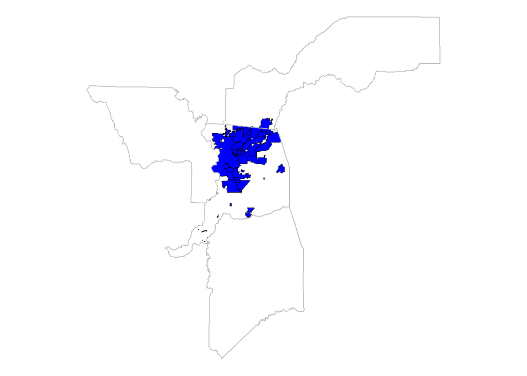

Figure 1: Water Systems and County Boundaries

```r
# make plot
plot_boundaries <- ggplot() +
    geom_sf(data = water_systems_sac,
            fill = alpha('blue', 1),
            color = 'black',
            linewidth = 0.1) +
    geom_sf(data = counties_ca %>%
                filter(NAME %in% counties_list),
            fill = NA,
            color = 'grey',
            linewidth = 0.5) +
    theme_void()

# show plot
plot_boundaries
```

## 4 Census Data (Source Data)

This section provides some brief background on the various types of data available from the U.S. Census Bureau, and demonstrates how to retrieve data from the U.S. Census Bureau using the [`tidycensus`](https://walker-data.com/tidycensus/index.html) R package. Most of the information covered here comes from the book [Analyzing US Census Data: Methods, Maps, and Models in R](https://walker-data.com/census-r/index.html), which is a great source of information if you’d like more detail about any of the topics below (Walker 2023b).

### 4.1 Census Data Overview

**Note**

If you’re already familiar with Census data and want to skip this overview, go directly to Section 4.2

Different census products/surveys contain data on different variables, at different geographic scales, over varying periods of time, and with varying levels of certainty. Therefore, there are a number of judgement calls to make when determining which type of census data to use for an analysis – e.g., which data product to use (Decennial Census or American Community Survey), which geographic scale to use (e.g., Block, Block Group, Tract, etc.), what time frame to use, which variables to assess, etc.

More detailed information about U.S. Census Bureau’s data products and other topics mentioned below is available [here](https://walker-data.com/census-r/the-united-states-census-and-the-r-programming-language.html#the-united-states-census-and-the-r-programming-language).

#### 4.1.1 Census Geography / Hierarchy

Data from the U.S. Census Bureau is aggregated to census units which are available at different geographic scales. Some of these units are nested and can be neatly aggregated (e.g., each census tract is composed of a collection of block groups, and each block group is composed of a collection of blocks), while other census units are outside this hierarchy (e.g., Zip Code Tabulation Areas don’t coincide with any other census unit). Figure 2 shows the relationship of all of the various census units.

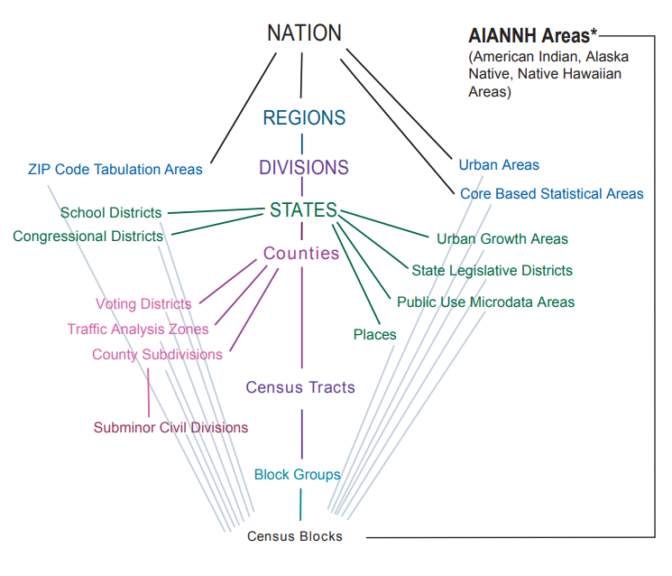

Figure 2: Census Unit Hierarchies

For a list of the different geographic units available for each of the different census products/surveys (see Section 4.1.2) that can be accessed via the `tidycensus` package, go [here](https://walker-data.com/tidycensus/articles/basic-usage.html#geography-in-tidycensus).

#### 4.1.2 Census Datasets / Surveys

The Decennial Census is conducted every 10 years, and is intended to provide a complete count of the US population and assist with political redistricting. As a result, it collects a relatively limited set of basic demographic data, but (should) provide a high degree of precision (i.e., in general it should provide exact counts). It is available for geographic units down to the census block (the smallest census unit available – see Section 4.1.1). For information about existing and planned future releases of 2020 census data products, go [here](https://www.census.gov/programs-surveys/decennial-census/decade/2020/planning-management/release/about-2020-data-products.html).

The American Community Survey (ACS) provides a much larger array of demographic information than the Decennial Census, and is updated more frequently. The ACS is based on a sample of the population (rather than a count of the entire population, as in the Decennial Census), so it represents estimated values rather than precise counts, therefore each data point is available as an estimate (typically labeled with an ‘E’ in census variable codes, which are discussed in Section 4.1.3 ) along with an associated margin of error (typically labeled with ‘MOE’ in census variable codes) around its estimated value.

The ACS is available in two formats. The 5-year ACS is a rolling average of 5 years of data (e.g., the 2021 5-year ACS dataset is an average of the ACS data from 2017 through 2021), and is generally available for geographic units down to the census block group (though some 5-year ACS data may only be available at less granular levels). The 1-year ACS provides data for a single year, and is only available for geographies with population greater than 65,000 (e.g., large cities and counties). Therefore, only the 5-year ACS will be useful for any analysis at a relatively fine scale (e.g., anything that requires data at or more detailed than the census tract level, or any analysis that considers smaller counties/cities – by definition, census tracts always contain significantly fewer than 65,000 people).

In addition to the Decennial Census and ACS data, a number of other census data products/surveys are also available. For example, see the `censusapi` R package ([here](https://github.com/hrecht/censusapi) or [here](https://www.hrecht.com/censusapi/index.html)) for access to over 300 census API endpoints. For historical census data, see the discussion [here](https://walker-data.com/census-r/other-census-and-government-data-resources.html?q=API%20endpoint#other-census-and-government-data-resources) on using NHGIS, IPUMS, and the `ipumsr` package.

#### 4.1.3 Census Variables / Codes

Each census product collects data for many different demographic variables, and each variable is generally associated with an identifier code. In order to access census data programmatically, you often need to know the code associated with each variable of interest. When determining which variables to use, you need to consider what census product contains those variables (see Section 4.1.2) and how they differ in terms of time frame, precision, spatial granularity (see Section 4.1.1), etc.

The `tidycensus` package offers a convenient generic way to search for variables across different census products using the `load_variables()` function, as described [here](https://walker-data.com/tidycensus/articles/basic-usage.html#searching-for-variables).

The following websites may also be helpful for exploring the various census data products and finding the variable names and codes they contain:

- Census Reporter (for ACS data): https://censusreporter.org/ (especially https://censusreporter.org/topics/table-codes/)
- Census Bureau’s list of variable codes, e.g.:
  - 2020 Census codes: https://api.census.gov/data/2020/dec/pl/variables.html
  - 2021 ACS 5 year codes: https://api.census.gov/data/2021/acs/acs5/variables.html
- Census Bureau’s data interface (for Decennial Census and ACS, and other census datasets): https://data.census.gov/cedsci/
- National Historical Geographic Information System (NHGIS) (for ACS data and historical decennial Census data): https://www.nhgis.org/

### 4.2 Accessing Census Data

The following sections demonstrate how to retrieve census data from the Decennial Census and the ACS using the [`tidycensus`](https://walker-data.com/tidycensus/index.html) R package.

In order to use the `tidycensus` R package, you’ll need to obtain a personal API from the US Census Bureau (which is free and available to anyone) by signing up here: http://api.census.gov/data/key_signup.html. Once you have your API key, you’ll need to register it in R by entering the command `census_api_key(key = "YOUR API KEY", install = TRUE)` in the console. Note that the `install = TRUE` argument means that the key is saved for all future R sessions, so you’ll only need to run that command once on your computer (rather than including it in your scripts). Alternatively, you could save your key to an environment variable and retrieve it using `Sys.getenv()` (to avoid entering your key into any scripts that could potentially be shared).

#### 4.2.1 Decennial Census

This section retrieves census data from the 2020 U.S. Decennial Census, using the `get_decennial` function from the `tidycensus` package. For this example we’re getting data at the ‘Block Group’ level (with the `geography = 'block group'` argument), for the counties defined above in the `counties_list` variable (with the `county = counties_list` argument). By setting the `geometry = TRUE` argument we’ll be able to get the spatial data – i.e., the boundaries of the census block groups – along with the tabular data defined in the `variables` argument (see Section 4.1.3 for information about how to find variable codes). Also, while by default the `tidycensus` package returns data in long/tidy format, we’re getting the data in wide format for this example (by specifying `output = 'wide'`) because it’ll be easier to work with for the method described below to estimate demographics for non-census geographies.

Note that, to the extent possible, using census data at the most granular spatial level should provide the best results when estimating demographics for areas whose boundaries don’t align with census unit boundaries. However, depending on the use case, it may require too much time and computational resources to use the most granular spatial data, and may not be necessary to obtain a reasonable estimate. As noted above, in general the most granular level of Decennial Census data available is at the ‘Block’ level (though Decennial Census data may not be available for all data types at the block level, due to data privacy issues), but this example gets data at the ‘Block Group’ level for speed and simplicity. Data at the ‘Block’ level may be a better choice for a real-world analysis if possible.

Also, as a side note, `tidycensus` returns the Census Bureau’s [cartographic boundary shapefiles](https://www.census.gov/geo/maps-data/data/tiger-cart-boundary.html) by default (as opposed to the [core TIGER/Line shapefiles](https://www.census.gov/geo/maps-data/data/tiger-line.html)). Those default cartographic boundary shapefiles are pre-clipped to the US coastline, and are smaller/faster to process (alternatively you can use `cb = FALSE` to get the TIGER/Line data) (see [here](https://walker-data.com/census-r/spatial-analysis-with-us-census-data.html#better-cartography-with-spatial-overlay)). So the default spatial data returned by `tidycensus` may be somewhat different than the default spatial data returned by the `tigris` package, but in general I find it’s best to use the default `tidycensus` spatial data.

```r
# get census data
census_data_decennial <- get_decennial(geography = 'block group', # can be 'block', 'block group', 'tract', 'county', etc.
                                       state = 'CA',
                                       county = counties_list,
                                       year = 2020,
                                       variables = c(
                                           'pop_hispanic_or_latino' = 'P2_002N', # Total Hispanic or Latino
                                           'pop_white' = 'P2_005N', # White (Not Hispanic or Latino)
                                           'pop_black_or_african_american' = 'P2_006N', # Black or African American (Not Hispanic or Latino)
                                           'pop_native_american_or_alaska_native' = 'P2_007N', # American Indian and Alaska Native (Not Hispanic or Latino)
                                           'pop_asian' = 'P2_008N', # Asian (Not Hispanic or Latino)
                                           'pop_pacific_islander' = 'P2_009N', # Native Hawaiian and Other Pacific Islander (Not Hispanic or Latino)
                                           'pop_other' = 'P2_010N', # Some other race (Not Hispanic or Latino)
                                           'pop_multiple' = 'P2_011N', # Two or more races (Not Hispanic or Latino)
                                           'pop_total' = 'P2_001N'
                                       ),
                                       output = 'wide', # can be 'wide' or 'tidy'
                                       geometry = TRUE,
                                       cache_table = TRUE)
```

The output is an sf object (i.e., a dataframe-like object that also includes spatial data), in wide format, where each row represents a census unit, and the population of each racial/ethnic group is reported in a separate column. Here’s a view of the contents and structure of the Decennial Census data that’s returned:

```r
glimpse(census_data_decennial)
```

```
Rows: 1,915
Columns: 12
$ GEOID                                <chr> "060770010004", "060770031061", "…
$ NAME                                 <chr> "Block Group 4, Census Tract 10, …
$ pop_hispanic_or_latino               <dbl> 292, 588, 603, 851, 158, 152, 263…
$ pop_white                            <dbl> 466, 603, 212, 1178, 801, 935, 18…
$ pop_black_or_african_american        <dbl> 19, 155, 26, 137, 7, 11, 50, 178,…
$ pop_native_american_or_alaska_native <dbl> 2, 3, 5, 17, 1, 4, 16, 9, 45, 4, …
$ pop_asian                            <dbl> 48, 150, 83, 426, 40, 75, 90, 302…
$ pop_pacific_islander                 <dbl> 1, 6, 1, 7, 0, 5, 4, 41, 2, 6, 3,…
$ pop_other                            <dbl> 7, 6, 0, 27, 1, 8, 7, 25, 4, 14, …
$ pop_multiple                         <dbl> 50, 108, 20, 215, 81, 103, 128, 2…
$ pop_total                            <dbl> 885, 1619, 950, 2858, 1089, 1293,…
$ geometry                             <MULTIPOLYGON [°]> MULTIPOLYGON (((-121…
```

#### 4.2.2 American Community Survey (ACS)

To get data from the ACS, you can use the `get_acs()` function, which is very similar to the `get_decennial()` function used above.

Note that for this dataset we’ve also included a statement to get median household income data (with the `'med_hh_income' = 'B19013_001E'` statement in the `variables` part of the function).

```r
# set year
acs_year <- 2021

# get census data
census_data_acs <- get_acs(geography = 'block group',
                           state = 'CA',
                           county = counties_list,
                           year = acs_year,
                           variables = c('pop_total' = 'B01003_001E',
                                         'pop_hispanic_or_latino' = 'B03002_012E', # Total Hispanic or Latino
                                         'pop_white' = 'B03002_003E', # White (Not Hispanic or Latino)
                                         'pop_black_or_african_american' = 'B03002_004E', # Black or African American (Not Hispanic or Latino)
                                         'pop_native_american_or_alaska_native' = 'B03002_005E', # American Indian and Alaska Native (Not Hispanic or Latino)
                                         'pop_asian' = 'B03002_006E', # Asian (Not Hispanic or Latino)
                                         'pop_pacific_islander' = 'B03002_007E', # Native Hawaiian and Other Pacific Islander (Not Hispanic or Latino)
                                         'pop_other' = 'B03002_008E', # Some other race (Not Hispanic or Latino)
                                         'pop_multiple' = 'B03002_009E', # Two or more races (Not Hispanic or Latino)
                                         'med_hh_income' = 'B19013_001E'
                           ),
                           output = 'wide', # can be 'wide' or 'tidy'
                           geometry = TRUE,
                           cache_table = TRUE)
```

The output is an sf object (i.e., a dataframe-like object that also includes spatial data), in wide format, where each row represents a census unit, and the population of each racial/ethnic group, as well as the median household income, is reported in a separate column. Here’s a view of the contents and structure of the 2021 5-year ACS data that’s returned:

```r
glimpse(census_data_acs)
```

```
Rows: 1,915
Columns: 23
$ GEOID                                <chr> "060670031013", "060670050042", "…
$ NAME                                 <chr> "Block Group 3, Census Tract 31.0…
$ pop_total                            <dbl> 966, 1569, 776, 1371, 829, 2804, …
$ B01003_001M                          <dbl> 404, 470, 163, 337, 376, 497, 454…
$ pop_hispanic_or_latino               <dbl> 566, 150, 523, 269, 79, 348, 764,…
$ B03002_012M                          <dbl> 387, 166, 163, 197, 89, 147, 350,…
$ pop_white                            <dbl> 285, 93, 30, 452, 406, 1275, 826,…
$ B03002_003M                          <dbl> 161, 100, 28, 198, 330, 347, 319,…
$ pop_black_or_african_american        <dbl> 0, 131, 79, 150, 23, 199, 214, 0,…
$ B03002_004M                          <dbl> 13, 235, 49, 120, 36, 164, 144, 1…
$ pop_native_american_or_alaska_native <dbl> 0, 0, 0, 0, 0, 0, 9, 0, 0, 20, 0,…
$ B03002_005M                          <dbl> 13, 13, 13, 13, 13, 13, 14, 13, 1…
$ pop_asian                            <dbl> 69, 880, 135, 447, 288, 917, 98, …
$ B03002_006M                          <dbl> 80, 406, 80, 308, 142, 444, 144, …
$ pop_pacific_islander                 <dbl> 20, 283, 0, 9, 0, 9, 0, 0, 236, 0…
$ B03002_007M                          <dbl> 30, 266, 13, 16, 13, 14, 13, 13, …
$ pop_other                            <dbl> 0, 0, 0, 0, 0, 0, 0, 0, 0, 0, 0, …
$ B03002_008M                          <dbl> 13, 13, 13, 13, 13, 13, 13, 13, 1…
$ pop_multiple                         <dbl> 26, 32, 9, 44, 33, 56, 78, 0, 47,…
$ B03002_009M                          <dbl> 31, 56, 11, 61, 92, 54, 69, 13, 4…
$ med_hh_income                        <dbl> 59375, 90915, 16308, 89010, 74956…
$ B19013_001M                          <dbl> 15177, 20379, 4356, 25760, 32283,…
$ geometry                             <MULTIPOLYGON [°]> MULTIPOLYGON (((-121…
```

Note that the dataset that’s returned includes fields corresponding to Margin of Error (MOE) for each variable we’ve requested (these are the fields that end with two digits and an M – e.g., “001M”), since, as noted above in Section 4.1.2 , the ACS is based on a sample of the population and reports estimated values. Because we won’t be incorporating those MOEs into the analysis below, we can drop them for this example.

```r
census_data_acs <- census_data_acs %>%
    select(-matches('\\d\\dM$')) # each "\\d" matches any single digit, the $ specifies "ends with"
```

Here’s a view of the contents and structure of the revised 2021 5-year ACS dataset:

```r
glimpse(census_data_acs)
```

```
Rows: 1,915
Columns: 13
$ GEOID                                <chr> "060670031013", "060670050042", "…
$ NAME                                 <chr> "Block Group 3, Census Tract 31.0…
$ pop_total                            <dbl> 966, 1569, 776, 1371, 829, 2804, …
$ pop_hispanic_or_latino               <dbl> 566, 150, 523, 269, 79, 348, 764,…
$ pop_white                            <dbl> 285, 93, 30, 452, 406, 1275, 826,…
$ pop_black_or_african_american        <dbl> 0, 131, 79, 150, 23, 199, 214, 0,…
$ pop_native_american_or_alaska_native <dbl> 0, 0, 0, 0, 0, 0, 9, 0, 0, 20, 0,…
$ pop_asian                            <dbl> 69, 880, 135, 447, 288, 917, 98, …
$ pop_pacific_islander                 <dbl> 20, 283, 0, 9, 0, 9, 0, 0, 236, 0…
$ pop_other                            <dbl> 0, 0, 0, 0, 0, 0, 0, 0, 0, 0, 0, …
$ pop_multiple                         <dbl> 26, 32, 9, 44, 33, 56, 78, 0, 47,…
$ med_hh_income                        <dbl> 59375, 90915, 16308, 89010, 74956…
$ geometry                             <MULTIPOLYGON [°]> MULTIPOLYGON (((-121…
```

#### 4.2.3 Plot Results

Figure 3 shows the datasets that we’ll use below to compute water system demographics (zoomed in to the area around the water systems in this study). Each water system – the target dataset – is shown with a different (randomly chosen) color. The boundaries of the census data – the source dataset – are shown in red; in this case we’ll use the 2021 5-year ACS dataset. County boundaries are shown in grey (Sacramento county is show with a bold grey line).

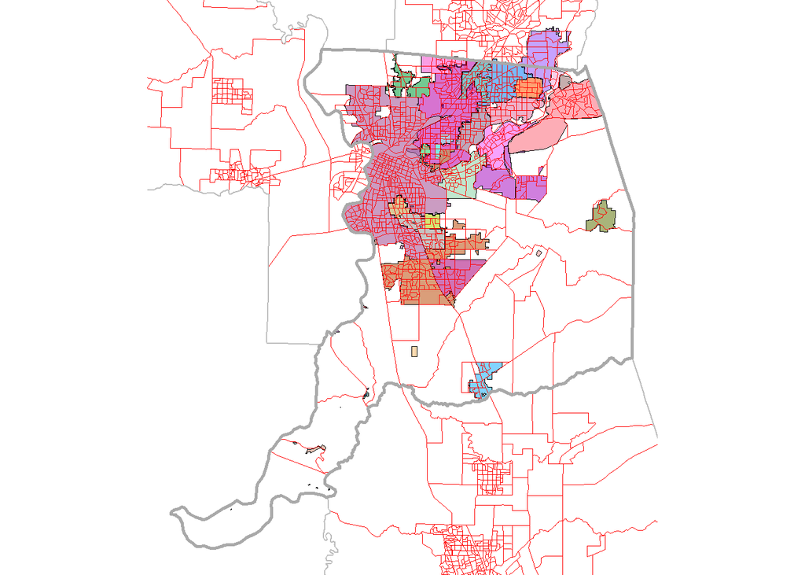

Figure 3: Water systems (filled polygons) and boundaries of census units (red) that will be used to estimate water system demographics, along with county boundaries (grey) for reference.

```r
# get the map boundaries, using the boundaries of the water suppliers and the
# Sacramento county boundary
bounds_map <- counties_ca %>%
    filter(NAME == 'Sacramento') %>%
    st_union(water_systems_sac) %>%
    st_buffer(100) %>%
    st_bbox()

# make a color palette with a distinct (random) color for supplier
set.seed(12345)
pal <- createPalette(nrow(water_systems_sac),
                     c("#FF0000", "#00FF00", "#0000FF"),
                     range = c(30, 80))

# make the plot
plot_census <- ggplot() +
    geom_sf(data = water_systems_sac,
            aes(fill = WATER_SYST, alpha = 0.8),
            # fill = alpha('blue', 0.8),
            color = 'black',
            linewidth = 0.1,
            show.legend = FALSE) +
    scale_fill_manual(values = unname(pal)) +
    geom_sf(data = census_data_acs %>%
                st_transform(crs_projected),
            fill = NA,
            color = alpha('red', 1),
            linewidth = 0.1) +
    geom_sf(data = counties_ca %>%
                filter(NAME %in% counties_list),
            fill = NA,
            color = 'grey',
            linewidth = 0.5) +
    geom_sf(data = counties_ca %>%
                filter(NAME == 'Sacramento'),
            fill = NA,
            color = 'darkgrey',
            linewidth = 1) + # bold line for Sacramento County
    coord_sf(xlim = c(bounds_map$xmin, bounds_map$xmax),
             ylim = c(bounds_map$ymin, bounds_map$ymax)) +
    theme_void()

# show the plot
plot_census
```

## 5 Compute Water System Demographics

Now we can perform the calculations to estimate demographic characteristics for our target areas (water system service boundaries in the Sacramento County area) from our source demographic dataset (the census data we obtained above). For this example, we’ll use the 2021 5-year ACS data that we retrieved above (which is saved in the `census_data_acs` variable) as our source of demographic data, and we’ll estimate the following for each water system’s service area:

- Population of each racial/ethnic group (using the racial/ethnic categories defined in the census dataset), and each racial/ethnic group’s portion of the total service area population
- Median household income

There are multiple ways this estimation can be done, but one of the most simple and straightforward is using an areal interpolation (essentially an area weighted average). The major simplifying assumption of this approach is that the population or other characteristic(s) of interest are evenly distributed within each unit in the source data – e.g., in this case we’re assuming that population (including the total population and the population of each racial/ethic group) and household income is evenly distributed within each census block group.

### 5.1 Prepare Census Data

To calculate demographics for the target areas, we need to prepare the census data. First, we need to transform the 2021 5-year ACS dataset into the common projected coordinate reference system defined above.

```r
# transform to common coordinate reference system
census_data_acs <- census_data_acs %>%
    st_transform(crs_projected)
```

We can then apply some transformations to the 2021 5-year ACS dataset prior to performing the areal interpolation to simplify the results and speed the computation.

This isn’t strictly necessary, but we can simplify the census dataset by filtering for census units that overlap with one of the water systems in our dataset.

```r
census_data_filter <- census_data_acs %>%
    st_filter(water_systems_sac,
              .predicate = st_intersects)
```

We can also drop census units with zero population, since they won’t contribute anything to our calculations.

```r
## drop census units with zero population
census_data_filter <- census_data_filter %>%
    filter(pop_total > 0)
```

You may also want to transform the census data in other ways. For example, we can combine the ‘other’ and ‘multiple’ racial/ethnic groupings into one ‘other or multiple’ racial/ethnic group.

```r
## combine other and multiple
census_data_filter <- census_data_filter %>%
    mutate('pop_other_or_multiple' = pop_other + pop_multiple,
           .before = med_hh_income) %>%
    select(-c(pop_other, pop_multiple))
```

Here’s a view of the contents and structure of the transformed census dataset:

```r
glimpse(census_data_filter)
```

```
Rows: 1,048
Columns: 12
$ GEOID                                <chr> "060670031013", "060670050042", "…
$ NAME                                 <chr> "Block Group 3, Census Tract 31.0…
$ pop_total                            <dbl> 966, 1569, 1989, 2865, 1398, 1641…
$ pop_hispanic_or_latino               <dbl> 566, 150, 764, 893, 96, 356, 280,…
$ pop_white                            <dbl> 285, 93, 826, 333, 1031, 986, 118…
$ pop_black_or_african_american        <dbl> 0, 131, 214, 328, 76, 48, 123, 24…
$ pop_native_american_or_alaska_native <dbl> 0, 0, 9, 0, 20, 0, 19, 9, 0, 0, 0…
$ pop_asian                            <dbl> 69, 880, 98, 1028, 32, 180, 34, 2…
$ pop_pacific_islander                 <dbl> 20, 283, 0, 236, 0, 0, 0, 0, 0, 0…
$ pop_other_or_multiple                <dbl> 26, 32, 78, 47, 143, 71, 84, 27, …
$ med_hh_income                        <dbl> 59375, 90915, 33952, 56023, 61806…
$ geometry                             <MULTIPOLYGON [m]> MULTIPOLYGON (((-123…
```

### 5.2 Areal Interpolation

There are a couple of ways to implement the areal interpolation method. The example below uses the [`aw_interpolate`](https://chris-prener.github.io/areal/reference/aw_interpolate.html) function from the [`areal`](https://chris-prener.github.io/areal/) R package. The `sf` package’s [`st_interpolate_aw`](https://r-spatial.github.io/sf/reference/interpolate_aw.html) function provides similar functionality. It’s also possible to ‘manually’ implement the process using lower level functions from the `sf` package, which can be useful for even more control, but is more complicated to implement (see Section 5.5 below for examples of ‘manual’ calculations that demonstrate how the interpolation function works and provide a check on the results).

Note that there are some settings that you may need to modify in the `aw_interpolate` function depending on the type of analysis you’re doing. In particular, for more information about extensive versus intensive interpolations, see [this section of the documenation](https://chris-prener.github.io/areal/articles/areal-weighted-interpolation.html#extensive-and-intensive-interpolations). For more information about the `weight` argument – which can be either `sum` or `total` – see [this section of the documentation](https://chris-prener.github.io/areal/articles/areal-weighted-interpolation.html#calculating-weights-for-extensive-interpolations).

```r
water_systems_sac_demographics <- water_systems_sac %>%
    aw_interpolate(tid = WATER_SY_1,
                   source = census_data_filter,
                   sid = GEOID,
                   weight = 'total',
                   output = 'sf',
                   extensive = c('pop_total',
                                 'pop_hispanic_or_latino',
                                 'pop_white',
                                 'pop_black_or_african_american',
                                 'pop_native_american_or_alaska_native',
                                 'pop_asian',
                                 'pop_pacific_islander',
                                 'pop_other_or_multiple'),
                   intensive = c('med_hh_income')
    )
```

We’ve now got a dataset with the selected census data (population of each racial/ethnic group and median household income) estimated for each of the target geographic features (water system service areas). Here’s a view of the contents and structure of the dataset:

```r
glimpse(water_systems_sac_demographics)
```

```
Rows: 62
Columns: 21
$ WATER_SY_1                           <chr> "HOOD WATER MAINTENCE DIST [SWS]"…
$ WATER_SYST                           <chr> "CA3400101", "CA3400179", "CA3400…
$ GLOBALID                             <chr> "{36268DB3-9DB2-4305-A85A-2C3A85F…
$ BOUNDARY_T                           <chr> "Water Service Area", "Water Serv…
$ OWNER_TYPE                           <chr> "L", "P", "P", "P", "P", "P", "P"…
$ COUNTY                               <chr> "SACRAMENTO", "SACRAMENTO", "SACR…
$ REGULATING                           <chr> "LPA64 - SACRAMENTO COUNTY", "LPA…
$ FEDERAL_CL                           <chr> "COMMUNITY", "COMMUNITY", "COMMUN…
$ STATE_CLAS                           <chr> "COMMUNITY", "COMMUNITY", "COMMUN…
$ SERVICE_CO                           <dbl> 82, 199, 34, 64, 128, 83, 28, 50,…
$ POPULATION                           <dbl> 100, 700, 40, 150, 256, 150, 32, …
$ pop_asian                            <dbl> 0.000000000, 69.954221829, 0.0519…
$ pop_black_or_african_american        <dbl> 0.000000000, 33.219002165, 0.0000…
$ pop_hispanic_or_latino               <dbl> 0.565201379, 32.478745849, 0.6368…
$ pop_native_american_or_alaska_native <dbl> 0.0000000, 0.0000000, 0.0000000, …
$ pop_other_or_multiple                <dbl> 0.016899709, 17.118427299, 0.0370…
$ pop_pacific_islander                 <dbl> 0.0000000, 0.0000000, 0.0000000, …
$ pop_total                            <dbl> 0.95013919, 310.44499237, 1.32067…
$ pop_white                            <dbl> 0.36803811, 157.67459523, 0.59484…
$ med_hh_income                        <dbl> 51250.00, 37833.00, 63076.00, 281…
$ geometry                             <MULTIPOLYGON [m]> MULTIPOLYGON (((-132…
```

Table 1 provides a complete view of the dataset:

```r
water_systems_sac_demographics %>%
    kable(caption = 'A Caption') %>%
    scroll_box(height = "400px")
```

Table 1: Water System Demographics

| WATER_SY_1 | WATER_SYST | GLOBALID | BOUNDARY_T | OWNER_TYPE | COUNTY | REGULATING | FEDERAL_CL | STATE_CLAS | SERVICE_CO | POPULATION | pop_asian | pop_black_or_african_american | pop_hispanic_or_latino | pop_native_american_or_alaska_native | pop_other_or_multiple | pop_pacific_islander | pop_total | pop_white | med_hh_income | geometry |
| --- | --- | --- | --- | --- | --- | --- | --- | --- | --- | --- | --- | --- | --- | --- | --- | --- | --- | --- | --- | --- |
| HOOD WATER MAINTENCE DIST [SWS] | CA3400101 | {36268DB3-9DB2-4305-A85A-2C3A85F20F34} | Water Service Area | L | SACRAMENTO | LPA64 - SACRAMENTO COUNTY | COMMUNITY | COMMUNITY | 82 | 100 | 0.0000000 | 0.0000000 | 0.5652014 | 0.0000000 | 0.0168997 | 0.0000000 | 0.9501392 | 0.3680381 | 51250.00 | MULTIPOLYGON (((-132703 403... |
| MC CLELLAN MHP | CA3400179 | {E3BF3C3E-D516-45B2-A5AD-6900F8D16715} | Water Service Area | P | SACRAMENTO | LPA64 - SACRAMENTO COUNTY | COMMUNITY | COMMUNITY | 199 | 700 | 69.9542218 | 33.2190022 | 32.4787458 | 0.0000000 | 17.1184273 | 0.0000000 | 310.4449924 | 157.6745952 | 37833.00 | MULTIPOLYGON (((-119809.2 7... |
| MAGNOLIA MUTUAL WATER | CA3400130 | {BADB48CD-AF05-4135-8FD5-9990BE415405} | Water Service Area | P | SACRAMENTO | LPA64 - SACRAMENTO COUNTY | COMMUNITY | COMMUNITY | 34 | 40 | 0.0519044 | 0.0000000 | 0.6368586 | 0.0000000 | 0.0370746 | 0.0000000 | 1.3206784 | 0.5948408 | 63076.00 | MULTIPOLYGON (((-137015.5 3... |
| KORTHS PIRATES LAIR | CA3400135 | {7A556C0E-57E2-499A-9B87-B5707C837DA8} | Water Service Area | P | SACRAMENTO | LPA64 - SACRAMENTO COUNTY | COMMUNITY | COMMUNITY | 64 | 150 | 0.0000000 | 0.0021296 | 0.0040226 | 0.0000000 | 0.0020113 | 0.0000000 | 0.0774941 | 0.0693306 | 28182.00 | MULTIPOLYGON (((-137297.1 1... |
| EL DORADO MOBILE HOME PARK | CA3400121 | {23B9391F-B6E7-44CE-A0EA-C2EE522857BF} | Water Service Area | P | SACRAMENTO | LPA64 - SACRAMENTO COUNTY | COMMUNITY | COMMUNITY | 128 | 256 | 14.4974901 | 28.1712591 | 84.8981806 | 0.0000000 | 4.9423262 | 0.0000000 | 144.5904977 | 12.0812417 | 34669.00 | MULTIPOLYGON (((-124533.7 5... |
| RIVER'S EDGE MARINA & RESORT | CA3400107 | {F56E068C-AE1B-4C68-A2AF-F5058871E4E2} | Water Service Area | P | SACRAMENTO | LPA64 - SACRAMENTO COUNTY | COMMUNITY | COMMUNITY | 83 | 150 | 0.0000000 | 0.0034012 | 0.0064244 | 0.0000000 | 0.0032122 | 0.0000000 | 0.1237642 | 0.1107264 | 28182.00 | MULTIPOLYGON (((-141320.7 1... |
| LAGUNA VILLAGE RV PARK | CA3400397 | {5184D6CC-8084-494D-BD81-B0009F76F1FD} | Water Service Area | P | SACRAMENTO | LPA64 - SACRAMENTO COUNTY | COMMUNITY | COMMUNITY | 28 | 32 | 10.2242604 | 2.1599596 | 2.4781982 | 0.0000000 | 2.2073569 | 2.3495486 | 20.7667593 | 1.3474356 | 75625.00 | MULTIPOLYGON (((-122362.2 4... |
| SPINDRIFT MARINA | CA3400169 | {3B1EC48B-B696-452E-A769-99EF03DE955E} | Water Service Area | P | SACRAMENTO | LPA64 - SACRAMENTO COUNTY | COMMUNITY | COMMUNITY | 50 | 100 | 0.0000000 | 0.0041508 | 0.0078405 | 0.0000000 | 0.0039202 | 0.0000000 | 0.1510446 | 0.1351330 | 28182.00 | MULTIPOLYGON (((-140144.2 1... |
| SAC CITY MOBILE HOME COMMUNITY LP | CA3400296 | {BBEBB4AF-57F6-4CBA-9746-6EDDFF0BB86B} | Water Service Area | P | SACRAMENTO | LPA64 - SACRAMENTO COUNTY | COMMUNITY | COMMUNITY | 164 | 350 | 145.8308169 | 11.2439649 | 94.7218858 | 0.0000000 | 0.0000000 | 0.0000000 | 271.5587876 | 19.7621201 | 24757.00 | MULTIPOLYGON (((-124542.8 5... |
| ORANGE VALE WATER COMPANY | CA3410016 | {E7FB0496-8E98-4C1C-B073-40B7F2308EE3} | Water Service Area | P | SACRAMENTO | DISTRICT 09 - SACRAMENTO | COMMUNITY | COMMUNITY | 5684 | 18005 | 638.5006903 | 253.8975219 | 2761.5393898 | 117.0175169 | 1336.8016502 | 85.6664824 | 17664.0999286 | 12470.6766769 | NA | MULTIPOLYGON (((-104831.8 7... |
| GOLDEN STATE WATER CO. - CORDOVA | CA3410015 | {D09864D9-0038-4D96-AA06-F1D0F4207324} | Water Service Area | P | SACRAMENTO | DISTRICT 09 - SACRAMENTO | COMMUNITY | COMMUNITY | 14798 | 44928 | 5760.1200187 | 3910.0527264 | 8800.3256555 | 70.1174047 | 2705.0865285 | 217.6984827 | 48557.8845811 | 27094.4837645 | NA | MULTIPOLYGON (((-105024.5 6... |
| HOLIDAY MOBILE VILLAGE | CA3400335 | {31419106-A98A-447B-AAF5-674FA6C8D17F} | Water Service Area | P | SACRAMENTO | LPA64 - SACRAMENTO COUNTY | COMMUNITY | COMMUNITY | 115 | 200 | 16.0215230 | 2.3420167 | 25.6557279 | 0.0000000 | 3.8057771 | 0.0000000 | 54.1325214 | 6.3074767 | 34806.00 | MULTIPOLYGON (((-123885.3 5... |
| SOUTHWEST TRACT W M D [SWS] | CA3400156 | {0B3A9348-87E2-475F-B9EB-8A0E7658CA58} | Water Service Area | L | SACRAMENTO | LPA64 - SACRAMENTO COUNTY | COMMUNITY | COMMUNITY | 33 | 150 | 56.3568264 | 22.1959193 | 35.0279351 | 2.0808674 | 6.6761164 | 0.9537309 | 145.3139092 | 22.0225137 | 43780.00 | MULTIPOLYGON (((-125846.9 5... |
| CARMICHAEL WATER DISTRICT | CA3410004 | {2E757010-FDE6-4A95-9D60-16E621A3CEAC} | Water Service Area | L | SACRAMENTO | DISTRICT 09 - SACRAMENTO | COMMUNITY | COMMUNITY | 11704 | 37897 | 3315.2872983 | 1658.1271778 | 6380.8124052 | 95.9377856 | 2225.4736800 | 383.8419349 | 39320.6444793 | 25261.1641976 | NA | MULTIPOLYGON (((-112199 690... |
| SCWA - ARDEN PARK VISTA | CA3410002 | {0FF3353C-7B37-44EC-A4B4-AB9A9D8BF79C} | Water Service Area | L | SACRAMENTO | DISTRICT 09 - SACRAMENTO | COMMUNITY | COMMUNITY | 3043 | 10035 | 428.7788531 | 188.6051923 | 889.1679096 | 0.6897107 | 317.7512609 | 10.0992783 | 7926.7820755 | 6091.6898707 | NA | MULTIPOLYGON (((-120321.1 6... |
| SCWA - LAGUNA/VINEYARD | CA3410029 | {0D088865-F70E-43D5-899E-1B988AB097B9} | Water Service Area | L | SACRAMENTO | DISTRICT 09 - SACRAMENTO | COMMUNITY | COMMUNITY | 47411 | 172666 | 48274.2123743 | 15370.6947918 | 28113.3303781 | 246.4339767 | 9584.5450531 | 2404.4229712 | 144909.7309183 | 40916.0913731 | NA | MULTIPOLYGON (((-125203.9 4... |
| RIO COSUMNES CORRECTIONAL CENTER [SWS] | CA3400229 | {887BC04D-196C-4104-AF6A-DE128C8105D0} | Water Service Area | L | SACRAMENTO | LPA64 - SACRAMENTO COUNTY | COMMUNITY | COMMUNITY | 13 | 2800 | 1.1302501 | 5.5220789 | 6.4747182 | 0.8396143 | 2.5026966 | 0.5328322 | 26.3671194 | 9.3649291 | NA | MULTIPOLYGON (((-124028.8 3... |
| SCWA MATHER-SUNRISE | CA3410704 | {4E3FC0F8-4DB3-4B03-AAEB-C965EE668712} | Water Service Area | L | SACRAMENTO | DISTRICT 09 - SACRAMENTO | COMMUNITY | COMMUNITY | 6921 | 22839 | 4383.9075203 | 1528.7786183 | 2469.5370667 | 37.6987330 | 1043.8565551 | 11.1329024 | 17688.1713378 | 8213.2599420 | NA | MULTIPOLYGON (((-108416.1 5... |
| TUNNEL TRAILER PARK | CA3400192 | {896615F1-429B-4829-8D45-45AF249034BC} | Water Service Area | P | SACRAMENTO | LPA64 - SACRAMENTO COUNTY | COMMUNITY | COMMUNITY | 21 | 44 | 0.0039500 | 0.0000000 | 0.0392480 | 0.0000000 | 0.0000000 | 0.0000000 | 0.0606789 | 0.0174809 | 142932.00 | MULTIPOLYGON (((-136156.2 2... |
| IMPERIAL MANOR MOBILEHOME COMMUNITY | CA3400190 | {1F6AA119-33B3-4518-92C8-62843A00AE53} | Water Service Area | P | SACRAMENTO | LPA64 - SACRAMENTO COUNTY | COMMUNITY | COMMUNITY | 186 | 200 | 4.0181038 | 48.2172452 | 53.7757752 | 0.0000000 | 24.3449817 | 0.0000000 | 294.0097188 | 163.6536129 | NA | MULTIPOLYGON (((-115157 740... |
| CALAM - ISLETON | CA3410012 | {24CB80A8-8A7C-46E9-8413-3346147E7444} | Water Service Area | P | SACRAMENTO | DISTRICT 09 - SACRAMENTO | COMMUNITY | COMMUNITY | 480 | 1581 | 1.4603852 | 0.4854714 | 11.4755791 | 0.0000000 | 0.7686631 | 0.0000000 | 36.4231542 | 22.2330555 | 76889.43 | MULTIPOLYGON (((-138559.3 1... |
| FOLSOM, CITY OF - ASHLAND | CA3410030 | {C83A0A46-997F-44BF-9441-C2DBC0D706CF} | Water Service Area | L | SACRAMENTO | DISTRICT 09 - SACRAMENTO | COMMUNITY | COMMUNITY | 1079 | 3538 | 187.4683142 | 53.9999436 | 328.0200032 | 1.4544477 | 308.1184512 | 0.7152267 | 3913.0776461 | 3033.3012595 | 77740.48 | MULTIPOLYGON (((-100505 774... |
| LOCKE WATER WORKS CO [SWS] | CA3400138 | {66BAF16E-A801-4313-B7B8-FF4E564CA9F6} | Water Service Area | P | SACRAMENTO | LPA64 - SACRAMENTO COUNTY | COMMUNITY | COMMUNITY | 44 | 80 | 0.0593296 | 0.0000000 | 0.7279642 | 0.0000000 | 0.0423783 | 0.0000000 | 1.5096075 | 0.6799355 | 63076.00 | MULTIPOLYGON (((-131976.7 2... |
| DEL PASO MANOR COUNTY WATER DI | CA3410007 | {BC88D650-D07A-47DF-A872-CD3F6142791A} | Water Service Area | L | SACRAMENTO | DISTRICT 09 - SACRAMENTO | COMMUNITY | COMMUNITY | 1796 | 4520 | 183.5370050 | 368.6315406 | 493.9255432 | 32.9753034 | 297.0159779 | 52.0865861 | 5563.2227041 | 4135.0507478 | NA | MULTIPOLYGON (((-120274.9 6... |
| EAST WALNUT GROVE [SWS] | CA3400106 | {6E5DA14E-1740-4320-A7E4-FD9B48240017} | Water Service Area | L | SACRAMENTO | LPA64 - SACRAMENTO COUNTY | COMMUNITY | COMMUNITY | 166 | 300 | 0.1937331 | 0.0000000 | 2.3770738 | 0.0000000 | 0.1383808 | 0.0000000 | 4.9294298 | 2.2202423 | 63076.00 | MULTIPOLYGON (((-132506.6 2... |
| FOLSOM STATE PRISON | CA3410032 | {CFEFFCD1-76A3-4403-A906-D04B910D61C5} | Water Service Area | S | SACRAMENTO | DISTRICT 09 - SACRAMENTO | COMMUNITY | COMMUNITY | 2790 | 9703 | 101.3545069 | 1782.6117887 | 1460.3244114 | 78.7320774 | 42.1594583 | 38.5787179 | 4250.6501854 | 746.8892248 | 137306.52 | MULTIPOLYGON (((-99838.11 7... |
| CALAM - ARDEN | CA3410045 | {FC35B709-C658-4890-B64C-374368BFAC79} | Water Service Area | P | SACRAMENTO | DISTRICT 09 - SACRAMENTO | COMMUNITY | COMMUNITY | 1185 | 3908 | 1287.8664116 | 2043.4413555 | 3473.6477252 | 19.2265978 | 722.4291781 | 32.9583296 | 10383.5256190 | 2803.9560211 | 46056.74 | MULTIPOLYGON (((-123013.9 6... |
| EDGEWATER MOBILE HOME PARK | CA3400433 | {FA333DDB-BCD6-4D29-9D40-664577E929C9} | Water Service Area | P | SACRAMENTO | LPA64 - SACRAMENTO COUNTY | COMMUNITY | COMMUNITY | 22 | 40 | 0.0000000 | 0.0014085 | 0.0026604 | 0.0000000 | 0.0013302 | 0.0000000 | 0.0512526 | 0.0458535 | 28182.00 | MULTIPOLYGON (((-153715.8 7... |
| CALAM - LINCOLN OAKS | CA3410013 | {488DCE2C-6EEA-4377-8984-5833F5D03CDF} | Water Service Area | P | SACRAMENTO | DISTRICT 09 - SACRAMENTO | COMMUNITY | COMMUNITY | 14390 | 47487 | 2179.4983222 | 1405.4342145 | 8930.0789685 | 157.2704873 | 2270.7880170 | 53.9455523 | 41854.4977649 | 26857.4822032 | NA | MULTIPOLYGON (((-113737.5 7... |
| VIEIRA'S RESORT, INC | CA3400164 | {C8E1FF09-C1ED-47D9-BD1C-AE3C754ABA72} | Water Service Area | P | SACRAMENTO | LPA64 - SACRAMENTO COUNTY | COMMUNITY | COMMUNITY | 107 | 150 | 0.1743588 | 0.0674937 | 1.3105034 | 0.0000000 | 0.1068651 | 0.0000000 | 4.6233209 | 2.9640999 | 49028.00 | MULTIPOLYGON (((-143708.1 1... |
| FLORIN COUNTY WATER DISTRICT | CA3410033 | {7D72D48E-DB2F-4E79-B396-70EEB030D102} | Water Service Area | L | SACRAMENTO | DISTRICT 09 - SACRAMENTO | COMMUNITY | COMMUNITY | 2323 | 7831 | 3034.6350014 | 1190.0162275 | 2889.5493141 | 3.9111704 | 585.4107984 | 851.9037907 | 10164.2899904 | 1608.8636879 | NA | MULTIPOLYGON (((-119638.3 5... |
| WESTERNER MOBILE HOME PARK | CA3400331 | {5DF48C4F-72B2-40C9-B2F7-10F9FF855DCC} | Water Service Area | P | SACRAMENTO | LPA64 - SACRAMENTO COUNTY | COMMUNITY | COMMUNITY | 49 | 65 | 8.7273597 | 7.1081326 | 5.5163500 | 0.2927416 | 0.9148176 | 0.1829635 | 28.4050858 | 5.6627208 | 55221.00 | MULTIPOLYGON (((-122693.1 4... |
| EL DORADO WEST MHP | CA3400122 | {2667CD45-9C2C-41B7-A95B-2F343B570215} | Water Service Area | P | SACRAMENTO | LPA64 - SACRAMENTO COUNTY | COMMUNITY | COMMUNITY | 128 | 172 | 15.3849195 | 29.8956959 | 90.0950213 | 0.0000000 | 5.2448589 | 0.0000000 | 153.4412620 | 12.8207663 | 34669.00 | MULTIPOLYGON (((-124742.1 5... |
| TOKAY PARK WATER CO | CA3400172 | {D2908483-C728-45ED-9A75-BA27D6E66685} | Water Service Area | P | SACRAMENTO | LPA64 - SACRAMENTO COUNTY | COMMUNITY | COMMUNITY | 198 | 525 | 223.4017737 | 60.8118891 | 205.9089514 | 3.7792611 | 10.7198679 | 0.0079639 | 641.4996076 | 136.8699006 | NA | MULTIPOLYGON (((-122789.8 5... |
| LAGUNA DEL SOL INC | CA3400181 | {F64FE571-B7DD-4F78-BBCF-2057DA131C24} | Water Service Area | P | SACRAMENTO | LPA64 - SACRAMENTO COUNTY | COMMUNITY | COMMUNITY | 112 | 470 | 0.3719700 | 0.0000000 | 11.6639169 | 0.4251086 | 0.3454007 | 0.0000000 | 30.7672342 | 17.9608379 | 88938.00 | MULTIPOLYGON (((-105025.5 4... |
| OLYMPIA MOBILODGE | CA3410022 | {B1E1B46F-9300-473E-B970-1D739E004B14} | Water Service Area | P | SACRAMENTO | DISTRICT 09 - SACRAMENTO | COMMUNITY | COMMUNITY | 200 | 450 | 113.3106690 | 19.1448282 | 77.0245412 | 0.0000000 | 0.0000000 | 15.1377711 | 314.7765933 | 90.1587838 | 37000.00 | MULTIPOLYGON (((-123549.9 5... |
| GOLDEN STATE WATER CO - ARDEN WATER SERV | CA3410003 | {E2997C83-F848-48AF-8915-B45E6469AC6E} | Water Service Area | P | SACRAMENTO | DISTRICT 09 - SACRAMENTO | COMMUNITY | COMMUNITY | 1716 | 5125 | 889.9806975 | 565.6406352 | 1500.7755281 | 0.1605332 | 772.9171556 | 0.9411931 | 6376.0546591 | 2645.6389164 | 56056.15 | MULTIPOLYGON (((-120307.3 6... |
| ELEVEN OAKS MOBILE HOME COMMUNITY | CA3400191 | {AB99BC88-8951-414B-BA24-E873AF46C168} | Water Service Area | P | SACRAMENTO | LPA64 - SACRAMENTO COUNTY | COMMUNITY | COMMUNITY | 136 | 262 | 60.6286759 | 28.7906014 | 28.1490281 | 0.0000000 | 14.8363823 | 0.0000000 | 269.0597984 | 136.6551107 | 37833.00 | MULTIPOLYGON (((-119816 721... |
| CALAM - ANTELOPE | CA3410031 | {AE6C5C3E-859C-4CD7-B3DF-5913A953F8F9} | Water Service Area | P | SACRAMENTO | DISTRICT 09 - SACRAMENTO | COMMUNITY | COMMUNITY | 10528 | 34720 | 3348.2880602 | 2885.0160018 | 6319.7633931 | 116.8965868 | 1768.4275981 | 42.6893023 | 34240.8066705 | 19759.7257281 | 89005.37 | MULTIPOLYGON (((-123334.7 8... |
| CALIFORNIA STATE FAIR | CA3410026 | {C97F5649-348B-4378-9C32-3B6D3E82725B} | Water Service Area | S | SACRAMENTO | DISTRICT 09 - SACRAMENTO | COMMUNITY | COMMUNITY | 269 | 650 | 10.6843192 | 47.0777815 | 74.1224645 | 0.0000000 | 31.7190727 | 0.0000000 | 406.0041301 | 242.4004921 | 51467.00 | MULTIPOLYGON (((-125658 651... |
| PLANTATION MOBILE HOME PARK | CA3400401 | {6BF6AFC4-25D1-4131-BA1A-CE81F4561902} | Water Service Area | P | SACRAMENTO | LPA64 - SACRAMENTO COUNTY | COMMUNITY | COMMUNITY | 44 | 44 | 3.3031812 | 0.4828570 | 5.2894795 | 0.0000000 | 0.7846427 | 0.0000000 | 11.1605823 | 1.3004218 | 34806.00 | MULTIPOLYGON (((-124338.4 5... |
| CALAM - PARKWAY | CA3410017 | {78A7BD82-DB23-4AC1-8736-574511C4CC84} | Water Service Area | P | SACRAMENTO | DISTRICT 09 - SACRAMENTO | COMMUNITY | COMMUNITY | 14779 | 48738 | 19304.1712813 | 6013.2947042 | 19227.0762182 | 71.5302392 | 3740.5020952 | 1249.9675094 | 59332.9972047 | 9726.4551571 | NA | MULTIPOLYGON (((-123335.4 5... |
| CITRUS HEIGHTS WATER DISTRICT | CA3410006 | {20EF35DA-A434-4A91-BE3D-7D996B8C6730} | Water Service Area | L | SACRAMENTO | DISTRICT 09 - SACRAMENTO | COMMUNITY | COMMUNITY | 19940 | 65911 | 2655.9016949 | 2171.4288977 | 11917.1661387 | 193.6811805 | 3525.0675772 | 84.1958205 | 68639.6218751 | 48092.1805655 | 82730.42 | MULTIPOLYGON (((-113645.4 7... |
| SEQUOIA WATER ASSOC | CA3400155 | {D4629F0D-8EAD-4402-88C8-D55C4121EA5B} | Water Service Area | P | SACRAMENTO | LPA64 - SACRAMENTO COUNTY | COMMUNITY | COMMUNITY | 18 | 54 | 0.0136700 | 0.0000000 | 0.1677281 | 0.0000000 | 0.0097643 | 0.0000000 | 0.3478243 | 0.1566620 | 63076.00 | MULTIPOLYGON (((-136917.7 3... |
| FAIR OAKS WATER DISTRICT | CA3410009 | {797F9D1A-2D43-4FA9-882A-DAA2A539318A} | Water Service Area | L | SACRAMENTO | DISTRICT 09 - SACRAMENTO | COMMUNITY | COMMUNITY | 14293 | 35114 | 1339.5550839 | 631.3430182 | 4652.8572407 | 76.4043080 | 1976.9059164 | 20.3231436 | 34830.8014807 | 26133.4127699 | 107111.66 | MULTIPOLYGON (((-107763.5 6... |
| RANCHO MARINA | CA3400149 | {A2E2869F-FE8D-48EF-8762-16238D0B3F9A} | Water Service Area | P | SACRAMENTO | LPA64 - SACRAMENTO COUNTY | COMMUNITY | COMMUNITY | 77 | 250 | 0.0000000 | 0.0066157 | 0.0124963 | 0.0000000 | 0.0062482 | 0.0000000 | 0.2407385 | 0.2153782 | 28182.00 | MULTIPOLYGON (((-138162.3 1... |
| FREEPORT MARINA | CA3400125 | {1A2ECBCF-8086-4599-91D1-7BDC9F543BC8} | Water Service Area | P | SACRAMENTO | LPA64 - SACRAMENTO COUNTY | COMMUNITY | COMMUNITY | 27 | 42 | 0.0000000 | 0.0000000 | 1.4745281 | 0.0000000 | 0.0440889 | 0.0000000 | 2.4787748 | 0.9601578 | 51250.00 | MULTIPOLYGON (((-130871.1 5... |
| HAPPY HARBOR (SWS) | CA3400128 | {95E0CED3-1431-4EF7-B516-D9DE2E6F03C4} | Water Service Area | P | SACRAMENTO | LPA64 - SACRAMENTO COUNTY | COMMUNITY | COMMUNITY | 45 | 60 | 0.0000000 | 0.0009397 | 0.0017751 | 0.0000000 | 0.0008875 | 0.0000000 | 0.0341960 | 0.0305937 | 28182.00 | MULTIPOLYGON (((-139870.3 1... |
| FOLSOM, CITY OF - MAIN | CA3410014 | {6E4D1E97-03EB-48F4-9F64-E74E49CC4CC2} | Water Service Area | L | SACRAMENTO | DISTRICT 09 - SACRAMENTO | COMMUNITY | COMMUNITY | 21424 | 68122 | 12307.2693273 | 1219.2933384 | 8446.0700840 | 81.8423449 | 3472.0678802 | 180.0452596 | 59990.2645442 | 34283.6763098 | NA | MULTIPOLYGON (((-107067.9 6... |
| RANCHO MURIETA COMMUNITY SERVI | CA3410005 | {2C72EE8A-A081-49FB-8EEA-808BF54CDB58} | Water Service Area | L | SACRAMENTO | DISTRICT 09 - SACRAMENTO | COMMUNITY | COMMUNITY | 2726 | 5744 | 161.4865649 | 135.5372737 | 568.4328917 | 20.7828569 | 29.5897581 | 0.0000000 | 3360.4987215 | 2444.6693762 | 115035.83 | MULTIPOLYGON (((-95334.2 52... |
| CAL AM FRUITRIDGE VISTA | CA3410023 | {501904B9-FD46-4D56-89DE-D87AD8F5FD70} | Water Service Area | P | SACRAMENTO | DISTRICT 09 - SACRAMENTO | COMMUNITY | COMMUNITY | 4667 | 15385 | 4274.0142794 | 2986.0491346 | 10210.4758703 | 143.1329988 | 1035.5138903 | 403.7080802 | 22324.5213227 | 3271.6270692 | NA | MULTIPOLYGON (((-125839.3 5... |
| B & W RESORT MARINA | CA3400103 | {CEC00BE2-7FBA-4B81-BE20-7D326EB6EBF6} | Water Service Area | P | SACRAMENTO | LPA64 - SACRAMENTO COUNTY | COMMUNITY | COMMUNITY | 37 | 100 | 0.0034512 | 0.0013359 | 0.0259394 | 0.0000000 | 0.0021152 | 0.0000000 | 0.0915114 | 0.0586697 | 49028.00 | MULTIPOLYGON (((-138335.4 1... |
| CALAM - SUBURBAN ROSEMONT | CA3410010 | {C7B2A772-B03D-4109-86B0-996D6A191F5F} | Water Service Area | P | SACRAMENTO | DISTRICT 09 - SACRAMENTO | COMMUNITY | COMMUNITY | 16238 | 53563 | 6628.9919050 | 7551.4572995 | 13719.8019730 | 123.8582366 | 4248.8635224 | 474.9945049 | 58297.9488839 | 25549.9814425 | NA | MULTIPOLYGON (((-120054.6 5... |
| SAN JUAN WATER DISTRICT | CA3410021 | {5F6CA8E6-CCFE-44C8-978B-6012BDE0AD70} | Water Service Area | L | SACRAMENTO | DISTRICT 09 - SACRAMENTO | COMMUNITY | COMMUNITY | 10672 | 29641 | 2527.9301100 | 894.3671483 | 3481.0035491 | 198.0670478 | 1302.1656240 | 15.4220389 | 29738.8522674 | 21319.8967493 | NA | MULTIPOLYGON (((-100141.1 8... |
| ELK GROVE WATER SERVICE | CA3410008 | {E33EFAB9-03BB-4AA6-B34C-E1B2B887AC40} | Water Service Area | P | SACRAMENTO | DISTRICT 09 - SACRAMENTO | COMMUNITY | COMMUNITY | 12882 | 42540 | 8610.3304149 | 3807.5697712 | 6825.0910992 | 104.5525436 | 2705.6895278 | 422.3658182 | 42589.0213336 | 20113.4221587 | 125534.47 | MULTIPOLYGON (((-113074.8 4... |
| DELTA CROSSING MHP | CA3400150 | {178C1128-CAD8-4118-8692-500FC1384637} | Water Service Area | P | SACRAMENTO | LPA64 - SACRAMENTO COUNTY | COMMUNITY | COMMUNITY | 22 | 30 | 0.0000000 | 0.0000000 | 0.0776949 | 0.0000000 | 0.0023231 | 0.0000000 | 0.1306101 | 0.0505920 | 51250.00 | MULTIPOLYGON (((-132728.4 4... |
| GALT, CITY OF | CA3410011 | {1EB5C880-698B-463D-916D-27EB4115BE84} | Water Service Area | L | SACRAMENTO | DISTRICT 09 - SACRAMENTO | COMMUNITY | COMMUNITY | 7471 | 26536 | 922.0534606 | 455.1824692 | 9936.0157552 | 21.5454675 | 880.5110932 | 16.1745727 | 21643.3873454 | 9411.9045270 | NA | MULTIPOLYGON (((-115624.6 2... |
| LINCOLN CHAN-HOME RANCH | CA3400137 | {8E59F56D-9D04-48D4-B6E4-F0584DA465D8} | Water Service Area | P | SACRAMENTO | LPA64 - SACRAMENTO COUNTY | COMMUNITY | COMMUNITY | 19 | 33 | 0.2167796 | 0.0000000 | 2.6598511 | 0.0000000 | 0.1548426 | 0.0000000 | 5.5158361 | 2.4843629 | 63076.00 | MULTIPOLYGON (((-137040.3 3... |
| RIO LINDA/ELVERTA COMMUNITY WATER DIST | CA3410018 | {03B163CA-7B3B-4A23-8E31-77AF963C2BF3} | Water Service Area | L | SACRAMENTO | DISTRICT 09 - SACRAMENTO | COMMUNITY | COMMUNITY | 4621 | 14381 | 837.1893410 | 211.3743010 | 2649.7541113 | 19.5727901 | 531.2294226 | 24.4541338 | 12137.4266769 | 7863.8525770 | 75806.08 | MULTIPOLYGON (((-125758.1 7... |
| SACRAMENTO SUBURBAN WATER DISTRICT | CA3410001 | {91C3BEAC-ACF7-4419-A57D-679912168873} | Water Service Area | L | SACRAMENTO | DISTRICT 09 - SACRAMENTO | COMMUNITY | COMMUNITY | 46573 | 184385 | 20628.6536443 | 17288.9657863 | 43073.5197326 | 414.3874546 | 10821.2002316 | 710.3592936 | 193283.3936775 | 100346.3075345 | NA | MULTIPOLYGON (((-115313.2 7... |
| CALAM - WALNUT GROVE | CA3410047 | {B1588BFA-E492-4087-BF44-72049EB4D5B5} | Water Service Area | P | SACRAMENTO | DISTRICT 09 - SACRAMENTO | COMMUNITY | COMMUNITY | 197 | 651 | 0.6652399 | 0.0000000 | 8.1623877 | 0.0000000 | 0.4751713 | 0.0000000 | 16.9266590 | 7.6238601 | 63076.00 | MULTIPOLYGON (((-132035.3 2... |
| CITY OF SACRAMENTO MAIN | CA3410020 | {8DB287D6-CBB3-484C-802F-FFC909F0959F} | Water Service Area | S | SACRAMENTO | DISTRICT 09 - SACRAMENTO | COMMUNITY | COMMUNITY | 142794 | 510931 | 95263.3900237 | 65993.7645135 | 148221.3050686 | 1354.3399308 | 32985.9322538 | 9243.5518769 | 512461.1530643 | 159398.8693972 | NA | MULTIPOLYGON (((-128741.8 5... |